# Classifying with logistic regression

Jose M Sallan

28/03/2020

```r
library(tidyverse)
library(caret)
```

# 1 A classification problem

Let’s introduce a classification problem on `mtcars`. This dataset contains data from the 1974 *Motor Trend* US magazine, and comprises fuel consumption and 10 aspects of automobile design and performance for 32 automobiles (1973–74 models).

Usually we use that dataset to predict fuel consumption `mpg`, but now we will use it for a classification problem: telling from available data if a car is offered by an American manufacturer or not. We know the names of the models, so we can define a factor variable indicating if the car is `american` or not.

```r
american <- c(0, 0 ,0 ,1 , 1 , 1, 1, 0, 0, 0, 0, 0, 0, 0, 1, 1, 1, 0, 0, 0, 0, 1, 1, 1, 1, 0, 0, 0, 1, 0, 0, 0)
names(american) <- row.names(mtcars)
american
```

```
##           Mazda RX4       Mazda RX4 Wag          Datsun 710
##                   0                   0                   0
##      Hornet 4 Drive   Hornet Sportabout             Valiant
##                   1                   1                   1
##          Duster 360           Merc 240D            Merc 230
##                   1                   0                   0
##            Merc 280           Merc 280C          Merc 450SE
##                   0                   0                   0
##          Merc 450SL         Merc 450SLC  Cadillac Fleetwood
##                   0                   0                   1
## Lincoln Continental   Chrysler Imperial            Fiat 128
##                   1                   1                   0
##         Honda Civic      Toyota Corolla       Toyota Corona
##                   0                   0                   0
##    Dodge Challenger         AMC Javelin          Camaro Z28
##                   1                   1                   1
##    Pontiac Firebird           Fiat X1-9       Porsche 914-2
##                   1                   0                   0
##        Lotus Europa      Ford Pantera L        Ferrari Dino
##                   0                   1                   0
##       Maserati Bora          Volvo 142E
##                   0                   0
```

Let’s add this variable to `mtcars` as a factor. This will be our target variable in the classification problem.

```r
mtcars <- mtcars  %>% mutate(american = as.factor(american))
```

# 2 Logistic regression

## 2.1 Introducing logistic regression

The original linear regression model takes an unbounded dependent variable, meaning that it can take any positive or negative value. In **logistic regression**, the response variable takes values zero and one, and the model predicts the probability of an observation taking the value 1 as a function of independent variables. We call this probability the **classification probability**.

We cannot use a model of ordinary least squares to estimate a linear regression model, as a predicted variable $\hat{y}_i$ can take values outside the (0, 1) interval. So instead of ordinary least squares regression, we use logistic regression. In logistic regression we obtain the classification probability $p_i$ of observation $i$ from its estimated value $\hat{y}_i$ with the **logit function**:

$$log\frac{p_i}{1-p_i} = \beta_0 + \beta_1x_{1i} + \beta_2x_{2i} + \dots + \beta_px_{pi} + \varepsilon_i$$

The logistic function takes the estimation $\hat{y}_i$ from the linear model, and turns it into a probability:

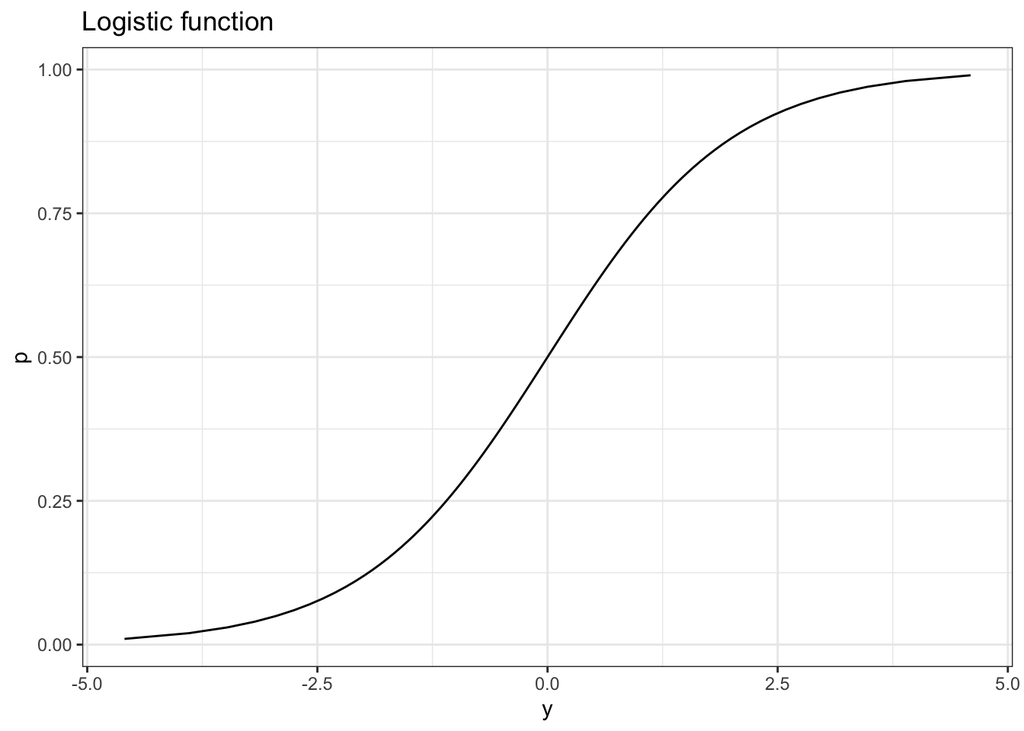

We can estimate a logistic regression model in R usimg the `glm` function for generalized linear models with the parameter `family='binomial'`.

## 2.2 A logistic regression model

Let’s see if we can tell if an observation of `mtcars` is an American car. To do so, we will build a logistic regression model with number of cylinders `cyl` and number of forward gears `gear`.

```r
lr <- glm(american  ~ cyl + gear, data=mtcars, family = "binomial")
summary(lr)
```

```
##
## Call:
## glm(formula = american ~ cyl + gear, family = "binomial", data = mtcars)
##
## Deviance Residuals:
##     Min       1Q   Median       3Q      Max
## -1.8314  -0.4498  -0.2233   0.6434   1.6239
##
## Coefficients:
##             Estimate Std. Error z value Pr(>|z|)
## (Intercept)  -2.6353     4.4316  -0.595   0.5521
## cyl           0.9776     0.4262   2.294   0.0218 *
## gear         -1.2386     0.7648  -1.619   0.1053
## ---
## Signif. codes:  0 '***' 0.001 '**' 0.01 '*' 0.05 '.' 0.1 ' ' 1
##
## (Dispersion parameter for binomial family taken to be 1)
##
##     Null deviance: 42.340  on 31  degrees of freedom
## Residual deviance: 22.915  on 29  degrees of freedom
## AIC: 28.915
##
## Number of Fisher Scoring iterations: 6
```

It looks like American cars tended to have more cylinders and less forward gears than non-American.

## 2.3 Classification probabilities

We can retrieve from `lr` the classification probabilities using `predict` with the `type="response"`. These are the probabilities of each observation being an American car, the value 1 in the dependent variable.

```r
prob_american <- predict(lr, mtcars, type="response")
```

Let’s see the distribution of probabilities for American and non-American cars:

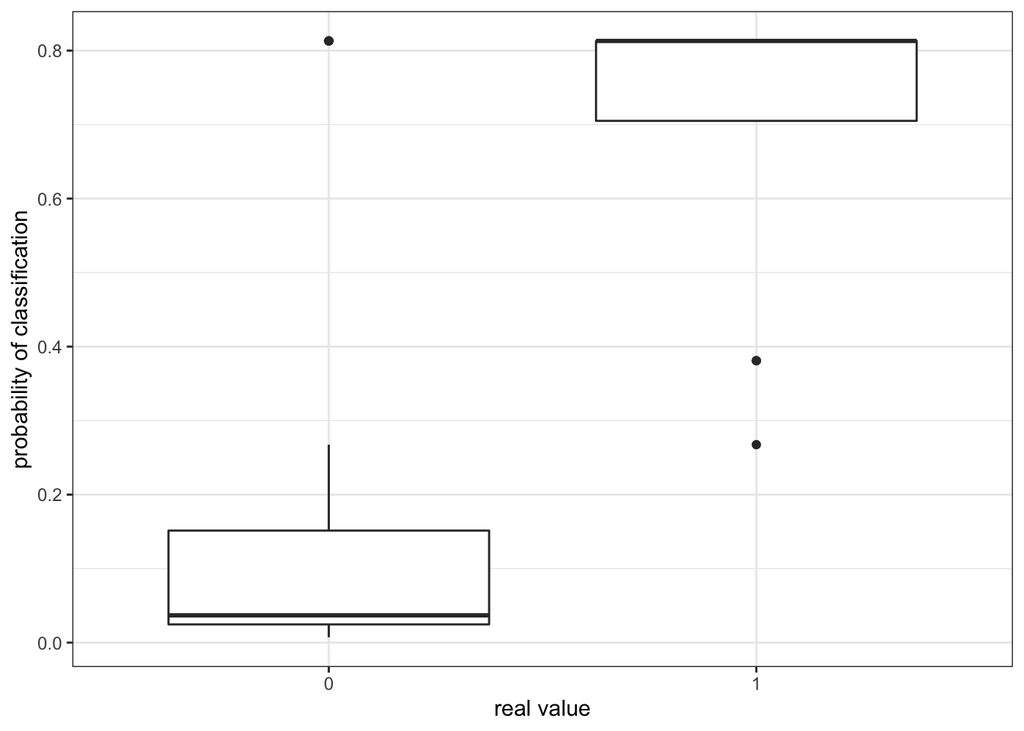

```r
data.frame(name=row.names(mtcars), real=as.factor(american), prob=prob_american) %>%
  ggplot(aes(real, prob)) +
  geom_boxplot() +
  theme_bw() +
  labs(x="real value", y="probability of classification")
```

Although there are outliers in both categories of data, in most cases the model assigns a high classification probability to American cars, and a low classification probability to non-American.

## 2.4 Prediction and confusion matrix

To assign a category to each observation we apply a **threshold value** to the classification probabilities. Observations with a probability above the threshold will be assigned to the class corresponding to the value 1 in the dependent variable. The other observations will be assigned probability zero.

The usual choice is selecting a threshold probability of 0.5:

```r
pred_american <- as.factor(ifelse(prob_american > 0.5, 1, 0))
```

We can obtain the `confusionMatrix` for this classification with the `caret` function. We set `positive="1"` to compute sensitivity and specificity correctly.

```r
confusionMatrix(pred_american, mtcars$american, positive="1")
```

```
## Confusion Matrix and Statistics
##
##           Reference
## Prediction  0  1
##          0 17  3
##          1  3  9
##
##                Accuracy : 0.8125
##                  95% CI : (0.6356, 0.9279)
##     No Information Rate : 0.625
##     P-Value [Acc > NIR] : 0.01877
##
##                   Kappa : 0.6
##
##  Mcnemar's Test P-Value : 1.00000
##
##             Sensitivity : 0.7500
##             Specificity : 0.8500
##          Pos Pred Value : 0.7500
##          Neg Pred Value : 0.8500
##              Prevalence : 0.3750
##          Detection Rate : 0.2812
##    Detection Prevalence : 0.3750
##       Balanced Accuracy : 0.8000
##
##        'Positive' Class : 1
##
```

# 3 Receiver operating characteristic (ROC) curve

The receiver operating characteristic curve was first developed by electrical engineers and radar engineers during World War II for detecting enemy objects in battlefields. Later, it has been used in many contexts where we need to assess the performance of a classifyer.

## 3.1 Definition of ROC

A **receiver operating characteristic curve**, or **ROC curve**, is a plot that illustrates the diagnostic ability of a binary classifier system as its discrimination threshold is varied.

The inputs of the ROC curve are the classification probabilities and the values of the target variable for a dataset. The ROC curve is created by plotting the true positive rate (TPR) against the false positive rate (FPR) at various threshold settings. Each point of the curve corresponds to a different threshold.

Let’s review what these FPR and TPR concepts are:

- The **false-positive rate FPR** is the rate between false positives to real negatives. It is also known as probability of false alarm, or Type-I error rate. It can be calculated as **1 - specificity**.
- The **true-positive rate TPR** is the rate of true positives to real positives. It is also known as **sensitivity**, recall or probability of detection.

Every ROC curve have two fixed points:

- For a threshold of zero all elements will be classified as positives. This means that `FPR=1` (all negatives have been classified incorrectly) and `TPR=1` (all positives have been correctly classified).
- For a threshold of one all elements will be classified as negatives. This means that `FPR=0` (all negatives have been classified correctly) and `TPR=0` (all positives have been classified incorrectly).

An ideal, perfect classifyer would have `FPR=0` and `TPR=1` for all other thresholds. Its ROC curve would look like this:

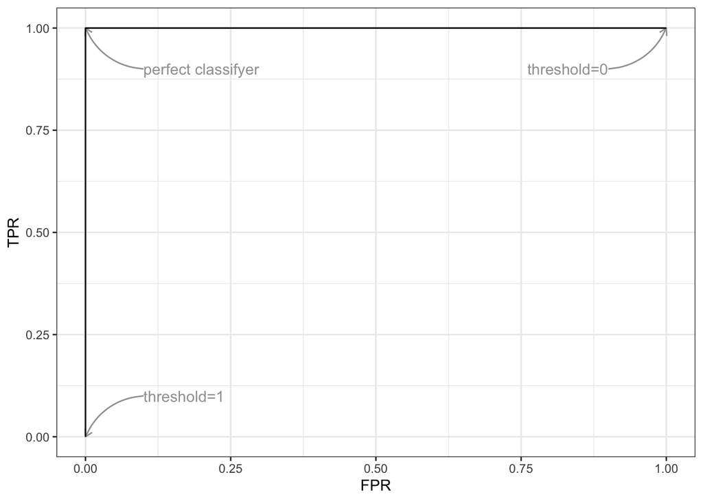

## 3.2 Obtaining a ROC curve for the logistic regression

Let’s calculate FPR and TPR for several threshold values for this classifyier:

```r
fpr_tpr <- function(real, prob, threshold){
  pred <- ifelse(prob > threshold, 1, 0)
  positives <- sum(real==1)
  negatives <- sum(real==0)
  true_positives <- sum(real==1 & pred==1)
  false_positives <- sum(real==0 & pred==1)
  fpr <- false_positives/negatives
  tpr <- true_positives/positives
  return(list(FPR=fpr, TPR=tpr))
}

table <- lapply(seq(0, 1, 0.1), function(x) fpr_tpr(american, prob_american, x))
roc <- data.frame(threshold=seq(0, 1, 0.1), FPR=sapply(table, function(x) x$FPR), TPR=sapply(table, function(x) x$TPR))
```

Let’s see the results:

```r
print(roc, digits = 3)
```

```
##    threshold  FPR   TPR
## 1        0.0 1.00 1.000
## 2        0.1 0.40 1.000
## 3        0.2 0.20 1.000
## 4        0.3 0.15 0.917
## 5        0.4 0.15 0.750
## 6        0.5 0.15 0.750
## 7        0.6 0.15 0.750
## 8        0.7 0.15 0.750
## 9        0.8 0.15 0.750
## 10       0.9 0.00 0.000
## 11       1.0 0.00 0.000
```

In this case, threshold values from 0.4 to 0.8 produce the same point, similarly to thresholds 0.9 and 1.0. Let’s see how the curve of our classifyer looks like:

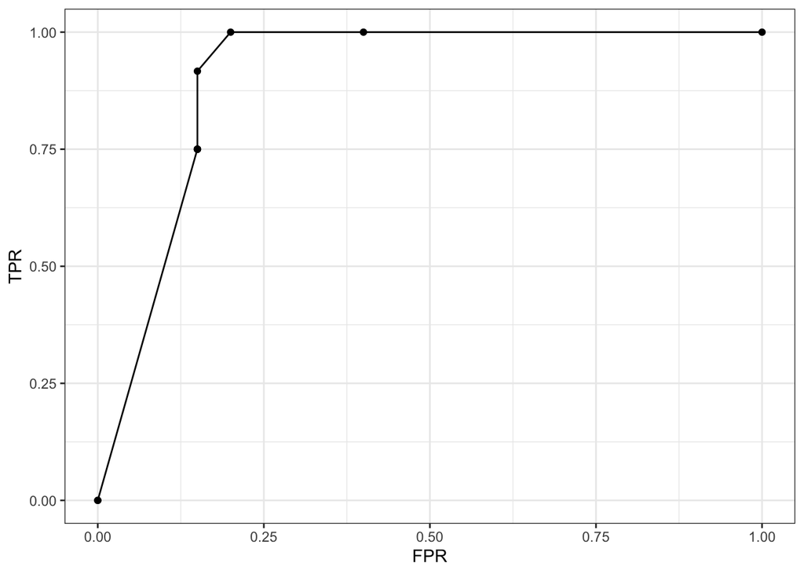

```r
ggplot(roc, aes(FPR, TPR)) +
  geom_point() +
  geom_path() +
  theme_bw()
```

Looks like it is a good classifyer, as it is close to the perfect classifyer of the above curve. If we want to collapse into into number the information of the ROC, we can define the AUC (area under curve) as the area defined here:

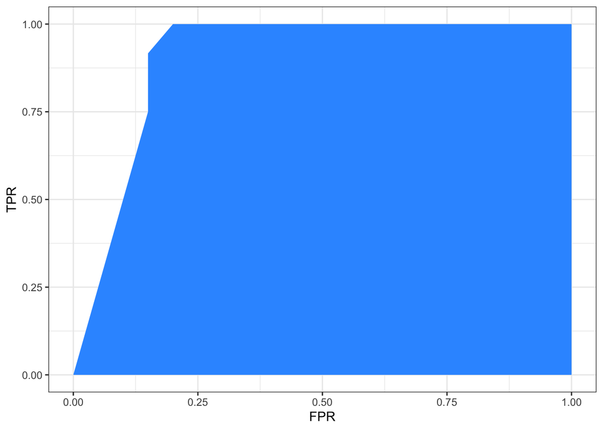

```r
ggplot(roc %>% add_row(threshold=-1, FPR=1, TPR=0), aes(FPR, TPR, fill=factor(1))) +
  geom_polygon(show.legend = FALSE) +
  scale_fill_manual(values = "#3399FF") +
  theme_bw()
```

We can obtain the value of the AUC using the `ROCR` package:

```r
library(ROCR)
pred_ROCR <- ROCR::prediction(prob_american, mtcars$american)
performance(pred_ROCR, measure = "auc")@y.values[[1]]
```

```
## [1] 0.9041667
```

A perfect classifyer has a AUC value equal to one. The worse classifyier possible has an AUC of 0.5. If we found a classifyer with an AUC of less than 0.5, we can obtain a better classifyer just reversing the prediction.

## 3.3 ROC as classification metric

ROC is widely appreciated as a performance metric for classification algorithms, as it allows to find a balance between sensitivity and specificity. Models with a AUC close to one are presumed to have high values of sensitivity and specificity. To make `caret` select a model according to ROC, you need to:

- Use `summaryFunction=twoClassSummary` and `classProbs=TRUE` in trainControl.
- Use `metric="ROC"` in `train`.

Then, it will use the AUC value to select a model.

## 3.4 Classification probabilities in decision trees and forests

We can define ROC and AUC for other classifyers like decision trees and random forests, if we are able to define a probability of classification to each observation, although it is not as natural as with logistc regression:

- For decision trees, the classification probability of an observation is the fraction of elements with target value equal to one in the leave (final subset) the observation belongs to. This definition makes sense if the tree is pruned, otherwise we can end with a single observation in each leave and all probabilities are equal to zero or one. Classification probabilities are quite unstable in decision trees (see https://rpmcruz.github.io/machine%20learning/2018/02/09/probabilities-trees.html).
- For random forests, the classification probability can be calculated as the proportion of decision trees that have assigned class one to the observation. These classification probabilities are more stable than for decision trees.